# Week5_Lab

JamesDale

2/21/2020

## Exercise 1

```r
names(nc)
```

```
##  [1] "fage"           "mage"           "mature"         "weeks"
##  [5] "premie"         "visits"         "marital"        "gained"
##  [9] "weight"         "lowbirthweight" "gender"         "habit"
## [13] "whitemom"
```

```r
summary(nc)
```

```
##       fage            mage            mature        weeks             premie
##  Min.   :14.00   Min.   :13   mature mom :133   Min.   :20.00   full term:846
##  1st Qu.:25.00   1st Qu.:22   younger mom:867   1st Qu.:37.00   premie   :152
##  Median :30.00   Median :27                     Median :39.00   NA's     :  2
##  Mean   :30.26   Mean   :27                     Mean   :38.33
##  3rd Qu.:35.00   3rd Qu.:32                     3rd Qu.:40.00
##  Max.   :55.00   Max.   :50                     Max.   :45.00
##  NA's   :171                                    NA's   :2
##      visits            marital        gained          weight
##  Min.   : 0.0   married    :386   Min.   : 0.00   Min.   : 1.000
##  1st Qu.:10.0   not married:613   1st Qu.:20.00   1st Qu.: 6.380
##  Median :12.0   NA's       :  1   Median :30.00   Median : 7.310
##  Mean   :12.1                     Mean   :30.33   Mean   : 7.101
##  3rd Qu.:15.0                     3rd Qu.:38.00   3rd Qu.: 8.060
##  Max.   :30.0                     Max.   :85.00   Max.   :11.750
##  NA's   :9                        NA's   :27
##  lowbirthweight    gender          habit          whitemom
##  low    :111    female:503   nonsmoker:873   not white:284
##  not low:889    male  :497   smoker   :126   white    :714
##                              NA's     :  1   NA's     :  2
##
##
##
##
```

## Exercise 2

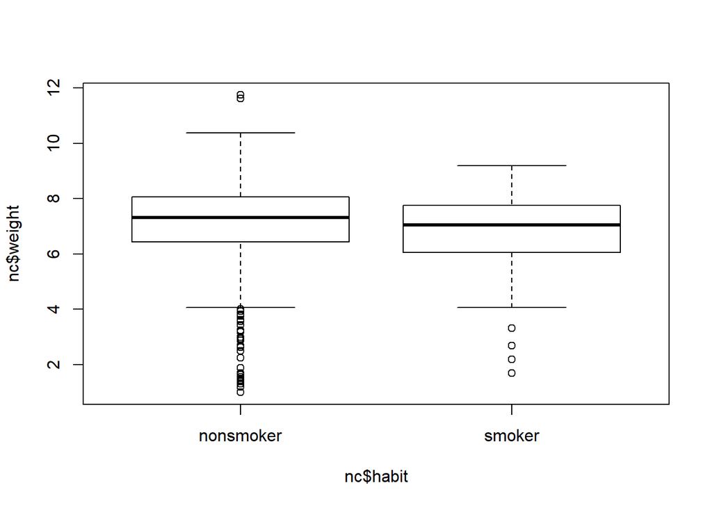

```r
nc$habit_bin <- ifelse(nc$habit == 'smoker', 1, 0)
nonsmokers <- subset(nc, habit_bin == 0)
smokers <- subset(nc, habit_bin == 1)

boxplot(nc$weight ~ nc$habit)
```

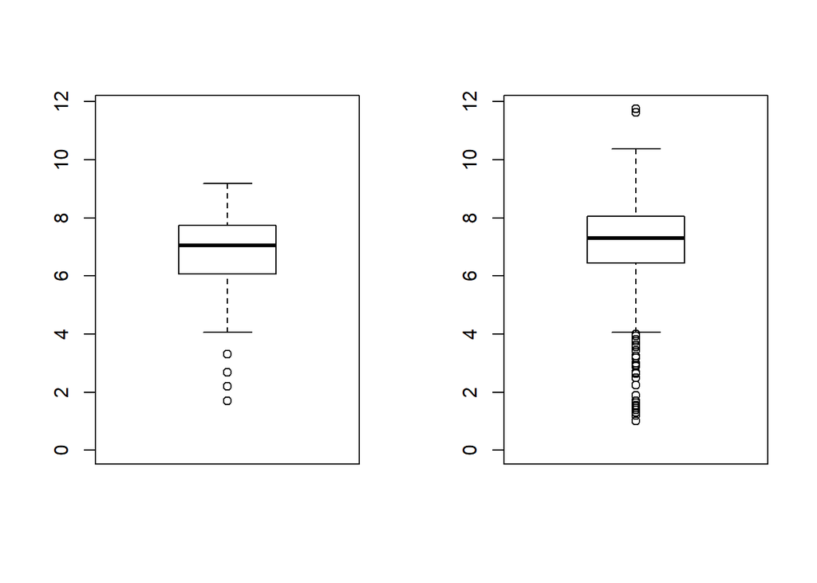

```r
smokers_max_x <- max(smokers$weight)
non_max_x <- max(nonsmokers$weight)
max_x <- ifelse(smokers_max_x > non_max_x, smokers_max_x, non_max_x)

par(mfrow=c(1,2))
boxplot(smokers$weight, ylim = c(0, max_x))
boxplot(nonsmokers$weight, ylim = c(0, max_x))
```

```r
by(nc$weight, nc$habit, mean)
```

```
## nc$habit: nonsmoker
## [1] 7.144273
## ------------------------------------------------------------
## nc$habit: smoker
## [1] 6.82873
```

## Exercise 3

### Checking conditions

- Independence: random sample/assignment, 10% condition when sampling without replacement
- Normality: nearly normal population or n ≥ 30, no extreme skew – or use the t distribution

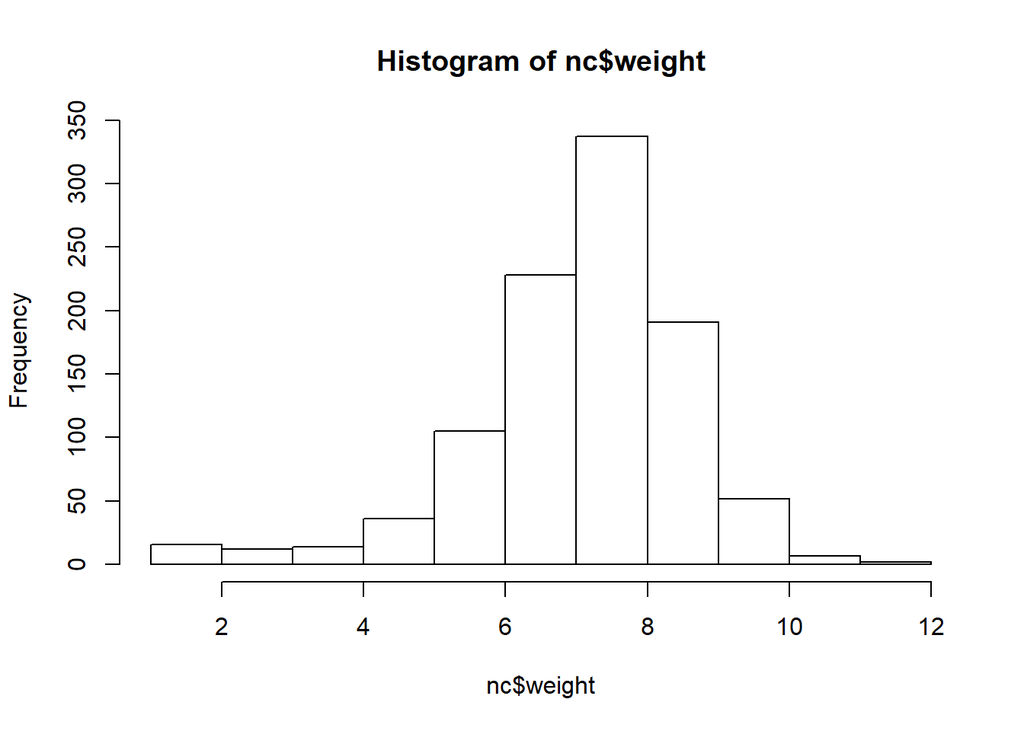

```r
hist(nc$weight)
```

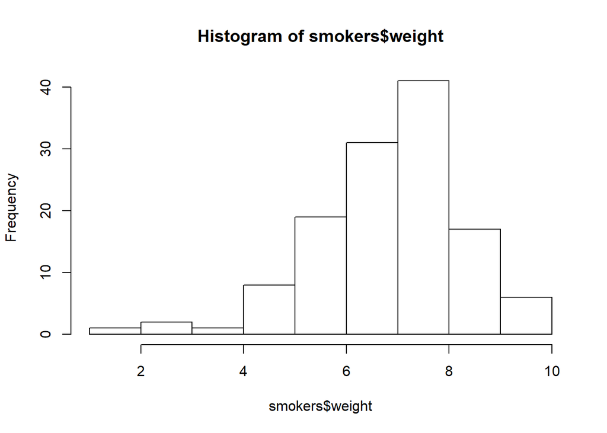

```r
hist(smokers$weight)
```

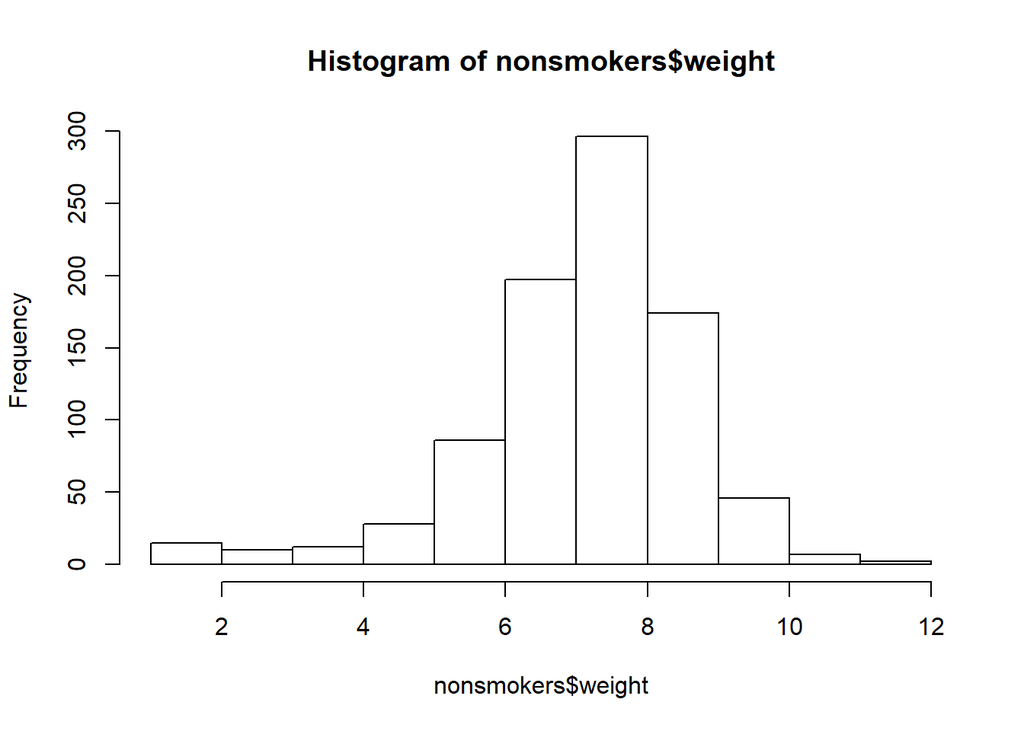

```r
hist(nonsmokers$weight)
```

```r
by(nc$weight, nc$habit, length)
```

```
## nc$habit: nonsmoker
## [1] 873
## ------------------------------------------------------------
## nc$habit: smoker
## [1] 126
```

We do see the skew in the total data as well as with each group but given the large sample size we can proceed with the hypothesis test.

## Exercise 4

### H0: µ smokers weight = µ non smokers weight

```r
inference(y = nc$weight, x = nc$habit, est = "mean", type = "ht", null = 0,
          alternative = "twosided", method = "theoretical")
```

```
## Response variable: numerical, Explanatory variable: categorical
## Difference between two means
## Summary statistics:
## n_nonsmoker = 873, mean_nonsmoker = 7.1443, sd_nonsmoker = 1.5187
## n_smoker = 126, mean_smoker = 6.8287, sd_smoker = 1.3862
```

```
## Observed difference between means (nonsmoker-smoker) = 0.3155
##
## H0: mu_nonsmoker - mu_smoker = 0
## HA: mu_nonsmoker - mu_smoker != 0
## Standard error = 0.134
## Test statistic: Z =  2.359
## p-value =  0.0184
```

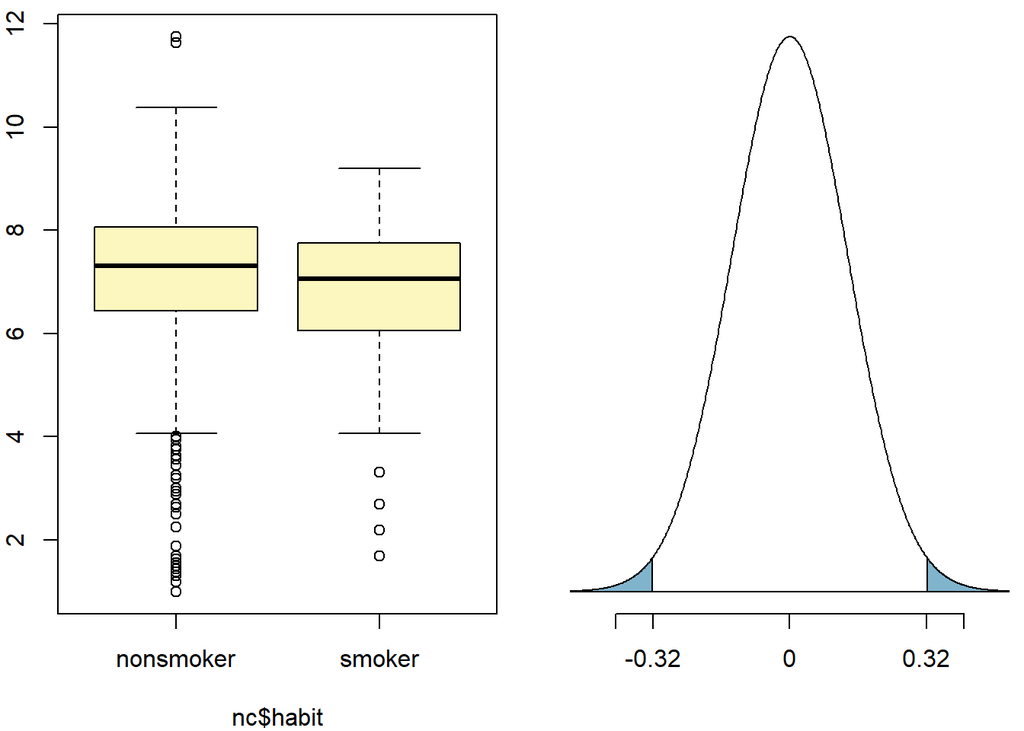

## Excercise 5

```r
inference(y = nc$weight, x = nc$habit, est = "mean", type = "ci", null = 0,
          alternative = "twosided", method = "theoretical",
          order = c("smoker","nonsmoker"))
```

```
## Response variable: numerical, Explanatory variable: categorical
## Difference between two means
## Summary statistics:
## n_smoker = 126, mean_smoker = 6.8287, sd_smoker = 1.3862
## n_nonsmoker = 873, mean_nonsmoker = 7.1443, sd_nonsmoker = 1.5187
```

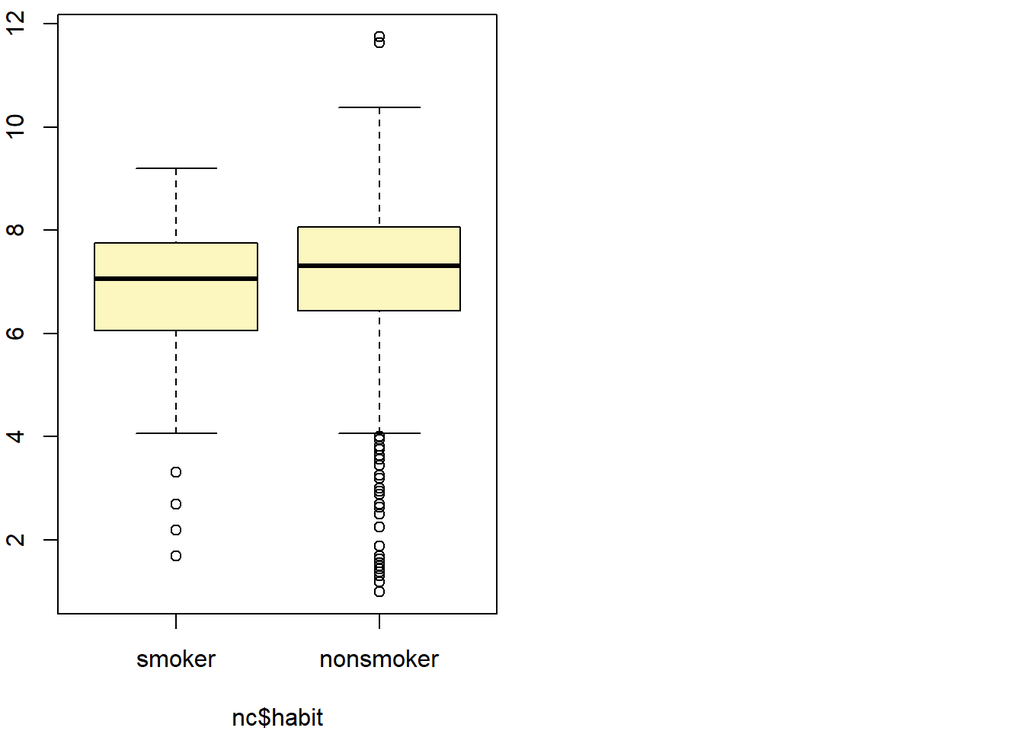

```
## Observed difference between means (smoker-nonsmoker) = -0.3155
##
## Standard error = 0.1338
## 95 % Confidence interval = ( -0.5777 , -0.0534 )
```

## Activity 1

#### Calculate a 95% confidence interval for the average length of pregnancies (weeks) and interpret it in context. Note that since you’re doing inference on a single population parameter, there is no explanatory variable, so you can omit the x variable from the function

```r
inference(y = nc$weeks, est = "mean", type = "ci",
           alternative = "twosided", method = "theoretical", conflevel = 0.95)
```

```
## Single mean
## Summary statistics:
```

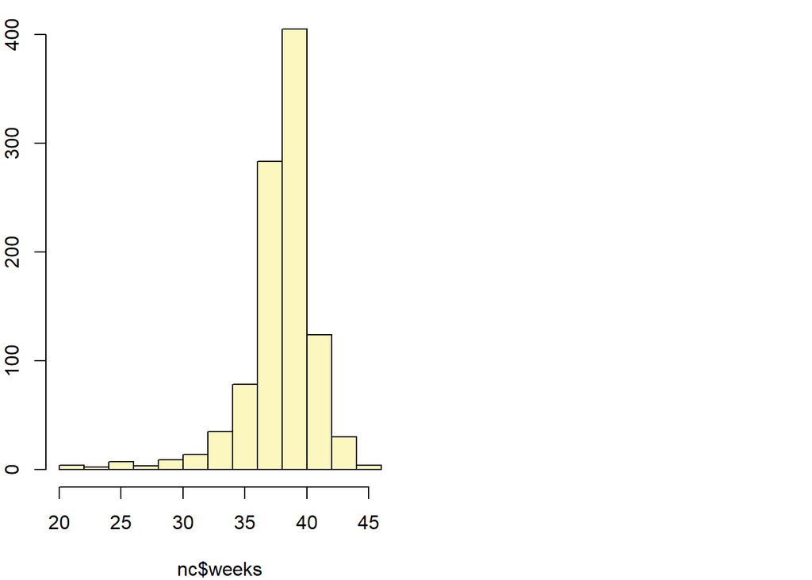

```
## mean = 38.3347 ;  sd = 2.9316 ;  n = 998
## Standard error = 0.0928
## 95 % Confidence interval = ( 38.1528 , 38.5165 )
```

We can interpret with 95% confidence the population mean is between **38.1528** and **38.5165**. This gives a tight range which usually is true of a more percise estimate.

## Activity 2

#### Calculate a new confidence interval for the same parameter at the 90% confidence level. You can change the confidence level by adding a new argument to the function: conflevel = 0.90

```r
inference(y = nc$weeks, est = "mean", type = "ci",
           alternative = "twosided", method = "theoretical", conflevel = 0.90)
```

```
## Single mean
## Summary statistics:
```

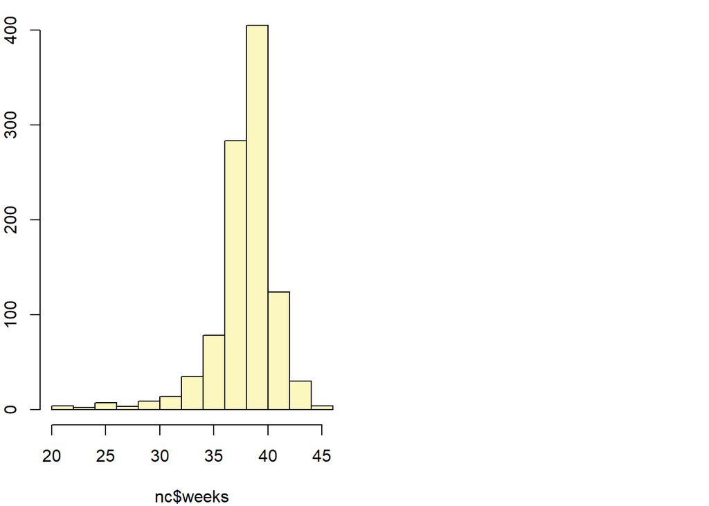

```
## mean = 38.3347 ;  sd = 2.9316 ;  n = 998
## Standard error = 0.0928
## 90 % Confidence interval = ( 38.182 , 38.4873 )
```

## Activity 3

#### Conduct a hypothesis test evaluating whether the average weight gained by younger mothers is different than the average weight gained by mature mothers.

### H0 µ younger moms = µ mature moms

### HA µ younger mom != µ mature moms

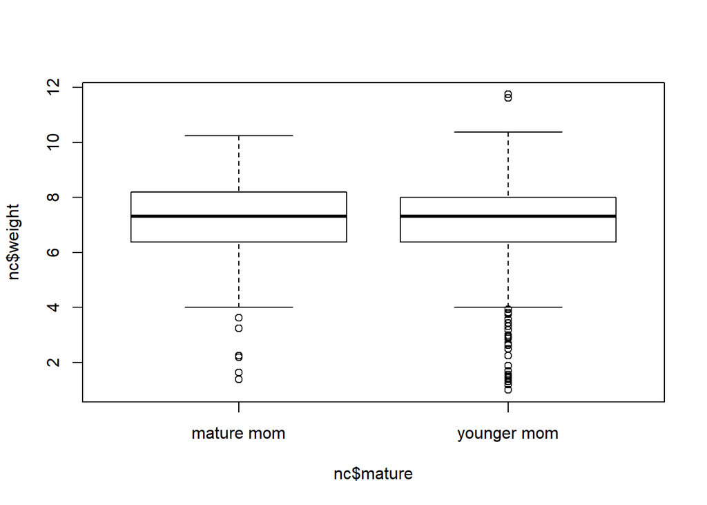

```r
boxplot(nc$weight ~ nc$mature)
```

```r
inference(y = nc$weight, x = nc$mature, est = "mean", type = "ci", null = 0,
          alternative = "twosided", method = "theoretical", order = c('younger mom', 'mature mom'))
```

```
## Response variable: numerical, Explanatory variable: categorical
## Difference between two means
## Summary statistics:
## n_younger mom = 867, mean_younger mom = 7.0972, sd_younger mom = 1.4855
## n_mature mom = 133, mean_mature mom = 7.1256, sd_mature mom = 1.6591
```

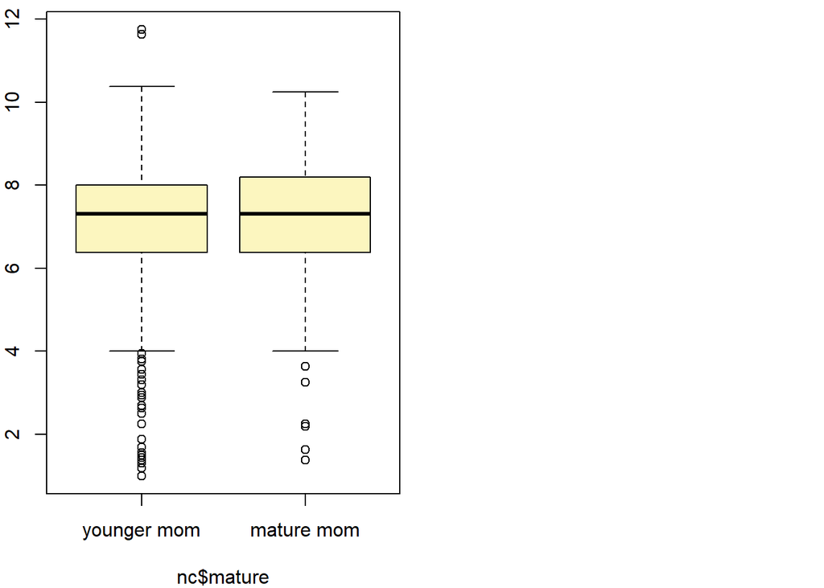

```
## Observed difference between means (younger mom-mature mom) = -0.0283
##
## Standard error = 0.1525
## 95 % Confidence interval = ( -0.3271 , 0.2705 )
```

```r
inference(y = nc$weight, x = nc$mature, est = "mean", type = "ht", null = 0,
          alternative = "twosided", method = "theoretical", order = c('younger mom', 'mature mom'))
```

```
## Response variable: numerical, Explanatory variable: categorical
## Difference between two means
## Summary statistics:
## n_younger mom = 867, mean_younger mom = 7.0972, sd_younger mom = 1.4855
## n_mature mom = 133, mean_mature mom = 7.1256, sd_mature mom = 1.6591
```

```
## Observed difference between means (younger mom-mature mom) = -0.0283
##
## H0: mu_younger mom - mu_mature mom = 0
## HA: mu_younger mom - mu_mature mom != 0
## Standard error = 0.152
## Test statistic: Z =  -0.186
## p-value =  0.8526
```

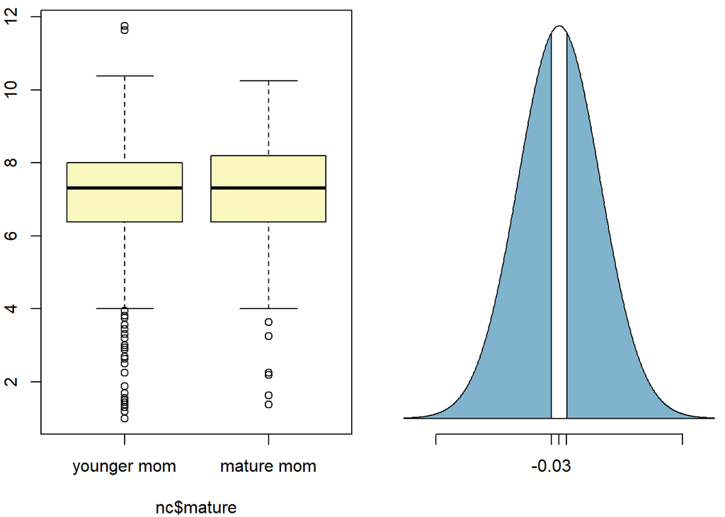

## Activity 4

#### Now, a non-inference task: Determine the age cutoff for younger and mature mothers. Use a method of your choice, and explain how your method works

```r
young <- subset(nc, nc$mature == 'younger mom')
mature <- subset(nc, nc$mature == 'mature mom')
max_young <- max(young$mage)
min_mature <- min(mature$mage)
```

#### The cutoff age for young mothers is **34**. If a mothers age is **35** they will be classfied as mature. I found this by subsetting the data into young mothers and mature mothers. Then got the max age of young mothers and the min age of mature mothers.

## Activity 5

#### Pick a pair of numerical and categorical variables and come up with a research question evaluating the relationship between these variables. Formulate the question in a way that it can be answered using a hypothesis test and/or a confidence interval. Answer your question using the inference function, report the statistical results, and also provide an explanation in plain language.

### H0 µ male baby weight = µ female baby weight

### HA µ male baby weight != µ female baby weight

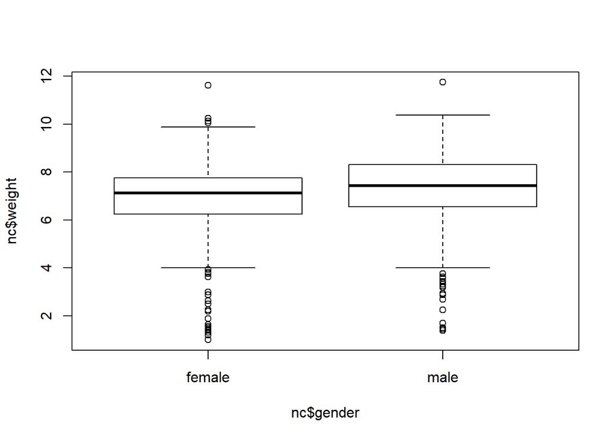

```r
boxplot(nc$weight ~ nc$gender)
```

```r
inference(y = nc$weight, x = nc$gender, est = "mean", type = "ci", null = 0,
          alternative = "twosided", method = "theoretical", order = c('male', 'female'))
```

```
## Response variable: numerical, Explanatory variable: categorical
## Difference between two means
## Summary statistics:
## n_male = 497, mean_male = 7.3015, sd_male = 1.5168
## n_female = 503, mean_female = 6.9029, sd_female = 1.4759
```

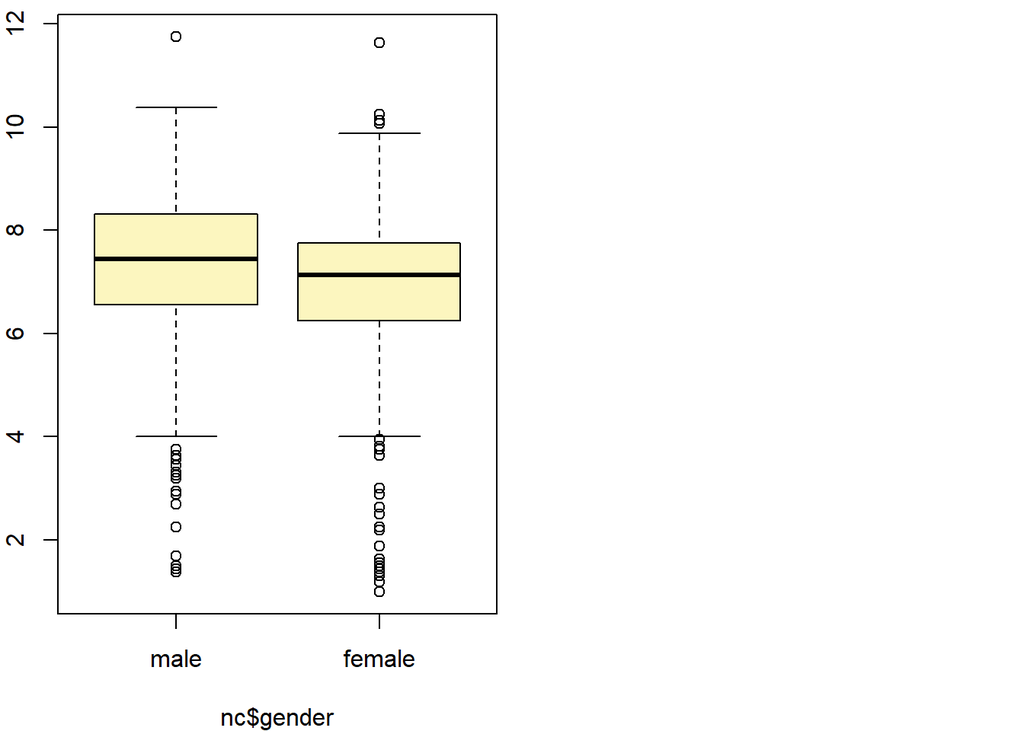

```
## Observed difference between means (male-female) = 0.3986
##
## Standard error = 0.0947
## 95 % Confidence interval = ( 0.2131 , 0.5841 )
```

```r
inference(y = nc$weight, x = nc$gender, est = "mean", type = "ht", null = 0,
          alternative = "twosided", method = "theoretical", order = c('male', 'female'))
```

```
## Response variable: numerical, Explanatory variable: categorical
## Difference between two means
## Summary statistics:
## n_male = 497, mean_male = 7.3015, sd_male = 1.5168
## n_female = 503, mean_female = 6.9029, sd_female = 1.4759
```

```
## Observed difference between means (male-female) = 0.3986
##
## H0: mu_male - mu_female = 0
## HA: mu_male - mu_female != 0
## Standard error = 0.095
## Test statistic: Z =  4.211
## p-value =  0
```

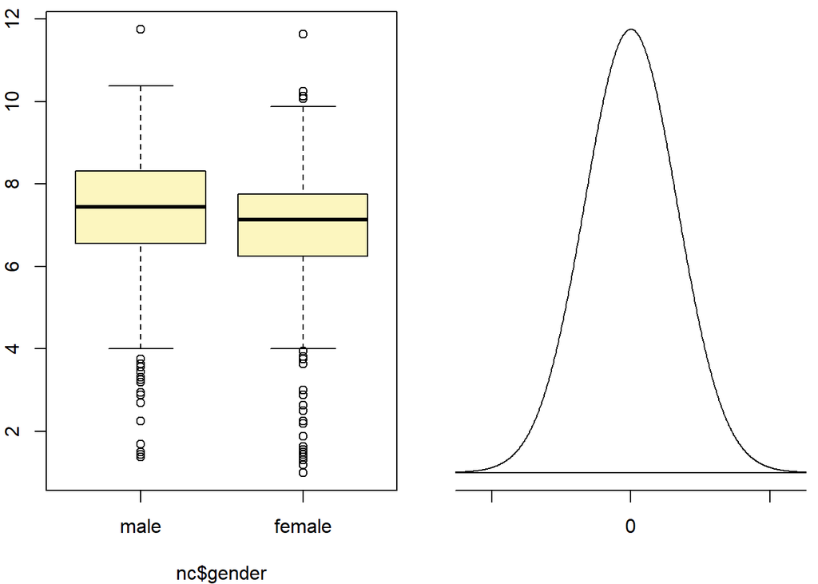

Although R gives the p value of 0, if we look at the z table for a two sided test we can see the P value is actually 0.000025. We can reject the null hypothesis and conclude that male weight is not equal to female weight.

### H0 µ male baby weight = µ female baby weight

### HA µ male baby weight > µ female baby weight

```r
inference(y = nc$weight, x = nc$gender, est = "mean", type = "ht", null = 0,
          alternative = "greater", method = "theoretical", order = c('male', 'female'))
```

```
## Response variable: numerical, Explanatory variable: categorical
## Difference between two means
## Summary statistics:
## n_male = 497, mean_male = 7.3015, sd_male = 1.5168
## n_female = 503, mean_female = 6.9029, sd_female = 1.4759
```

```
## Observed difference between means (male-female) = 0.3986
##
## H0: mu_male - mu_female = 0
## HA: mu_male - mu_female > 0
## Standard error = 0.095
## Test statistic: Z =  4.211
## p-value =  0
```

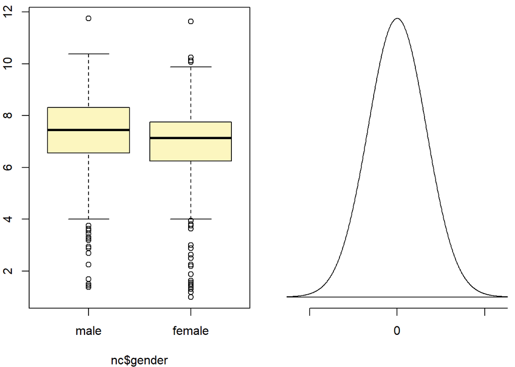

If we look a little further we can conclude male weights are greater than femaile weights